# ML Optimized CC Cookies

Anyone who knows me knows my love of baking, and if you call me a friend chances are I have baked you cookies at least a dozen times. Chocolate chip cookies are my specialty, and when thinking of practical applications of my new data science skills I could think of nothing better than to use a machine learning algorithm to develop the perfect chocolate chip cookie recipe.

My chocolate chip cookie recipe is based on [allrecipes.com's top-rated chocolate chip cookie recipe](https://www.allrecipes.com/recipe/10813/best-chocolate-chip-cookies/), so I decided to start there. The great thing about allrecipes is that it has such a large database with loads of chocolate chip cookie recipes to choose from.

## Scraping the Data

After importing some useful libraries I got to work searching for recipes to feed my machine learning algorithm. I searched allrecipes website and settled on 30 recipes, all rated 4.5 stars and up.

```python
# Import libraries
import pandas as pd
import numpy as np
import matplotlib.pyplot as plt
import requests
import re
from bs4 import BeautifulSoup
from sklearn.preprocessing import Normalizer
from scipy.cluster import hierarchy
from sklearn.cluster import KMeans
%matplotlib inline
```

```python
recipes = ['10813/best-chocolate-chip-cookies/', '10141/outrageous-chocolate-chip-cookies/', '10331/moms-chocolate-chip-cookies/',
          '15475/stephens-chocolate-chip-cookies/', '22848/ashleys-chocolate-chip-cookies/', '10909/annas-chocolate-chip-cookies/',
          '10337/beths-chocolate-chip-cookies/', '10823/the-ultimate-chocolate-chip-cookie/', '10524/toffee-chocolate-chip-cookies/',
          '15581/amys-chocolate-chip-cookies/', '9948/chocolate-chip-cookies-i/','9827/chocolate-chocolate-chip-cookies-i/',
          '17209/absolutely-the-best-chocolate-chip-cookies/','244631/chef-johns-chocolate-chip-cookies/','25040/chocolate-chip-cookies-v/',
          '232196/tiffanys-chocolate-chip-cookies/','219113/amenas-triple-chocolate-chip-cookies/','15330/jacks-chocolate-chip-cookies/',
          '10050/zippy-chocolate-chip-cookies/','10377/chocolate-chip-chunk-cookies/','25124/the-best-chocolate-chip-cookies/',
          '10180/georges-chocolate-chip-cookies/','10605/chocolate-chip-oatmeal-cookies/','10689/golden-chocolate-chip-cookies/',
          '19191/giant-chocolate-chip-cookies/','24423/easy-chocolate-chip-cookies/','10356/never-fail-chocolate-chip-cookies/',
          '10711/soft-chocolate-chip-cookies-ii/','15476/sues-two-chocolate-chip-cookies/','10995/chocolate-chocolate-chip-cookies-iii/']
```

After inspecting allrecipes website I found that all of the ingredients had a 'label' tag in the code, so using BeautifulSoup I scraped the website and collected all of the data from each webpage containing the 'label' tag.

```python
data = {}
for f in recipes:
    # Connect to the URL to scrape from
    response = requests.get("https://www.allrecipes.com/recipe/{0}".format(f))
    # Parse HTML and save to BeautifulSoup object
    soup = BeautifulSoup(response.text, "html.parser")
    # Store all data with 'label' tags
    ingredients_list = soup.find_all('label')

    # Create empty dataframe
    recipe = pd.DataFrame(columns=['Ingredients'])
    for i in range(len(ingredients_list)):
        # Store individual ingredients
        item = ingredients_list[i]
        # Convert to plain text
        item = item.text
        # Add ingredient to dataframe
        recipe = recipe.append({'Ingredients': item}, ignore_index=True)

    # Remove newline characters
    recipe.replace('\n','', regex=True, inplace=True)
    # Remove lines not starting with a number (non-ingredient 'label' tag items)
    recipe = recipe[recipe.Ingredients.str.contains('^[0-9]')]
    # Reset 0 based indexing
    recipe.index = np.arange(0, len(recipe))
    # Add recipe to library
    data[f.split('/',2)[1]] = recipe
```

Next I went about moving this data into a master dataframe, to do this required a bit of tidying up.

```python
# Create a master dataframe to collect all of the recipes
master = pd.DataFrame(columns=['Ingredients','Units'])
i = 0
for k,v in data.items():
    for j in range(len(v)):
        # If the 2nd word is a number (e.g. 1 1/2), replace the ' ' with a '_' for ease in splitting data
        if re.match(r'^[0-9]', v.at[j, 'Ingredients'].split(' ', 1)[1]):
            v.at[j, 'Ingredients'] = v.at[j, 'Ingredients'].split(' ', 1)[0] + '_' + v.at[j, 'Ingredients'].split(' ', 1)[1]
        # If ingredient is 'egg' there will be no unit measurement, so add one as place holder
        if 'egg' in v.at[j, 'Ingredients']:
            v.at[j, 'Ingredients'] = v['Ingredients'][j].split(' ', 1)[0] + ' units eggs'
        # Add ingredients to list splitting by ingredient name, unit, and recipe number (i)
        master = master.append({i: v.at[j, 'Ingredients'].split(' ', 2)[0],
                                'Units': v.at[j, 'Ingredients'].split(' ', 2)[1],
                                'Ingredients': v.at[j, 'Ingredients'].split(' ', 2)[2]}, ignore_index=True)
    i+=1

# Once data is split, remove the '_'
master.replace('[_]',' ',regex=True,inplace=True)
# Replace all NaN with 0s
master.fillna(0, inplace=True)
```

Some of the measurements were stored as string fractions, so I needed to convert them to floats.

```python
for i in range(len(master)):
    for j in range(len(recipes)):
        # Inspect if measurement is a string
        if isinstance(master.at[i, j], str):
            # If string contains '/' perform conversion
            if '/' in master.at[i, j]:
                num,den = master.at[i, j].split('/')
                # If there is a leading number before fraction, split that, else store as 0
                if len(num.split(' ')) == 2:
                    whole, num = num.split(' ')
                else:
                    whole = 0
                master.at[i, j] = float(whole) + (float(num)/float(den))
            # If string does not contain '/' simply convert to float
            else:
                master.at[i, j] = float(master.at[i, j])
```

To simplify the recipes and reduce small variations in the ingredient data (e.g. 'softened butter' vs 'butter', or 'granulated sugar vs white sugar') I replaced variations on any standard cookie ingredients with simplified versions.

```python
master['Ingredients'] = master['Ingredients'].str.lower()
for i in range(len(master)):
    if 'brown butter' in master.at[i, 'Ingredients']:
        master.at[i, 'Ingredients'] = 'brown butter'
    if 'butter' in master.at[i, 'Ingredients'] and 'brown' not in master.at[i, 'Ingredients']:
        master.at[i, 'Ingredients'] = 'butter'
    if 'flour' in master.at[i, 'Ingredients']:
        master.at[i, 'Ingredients'] = 'flour'
    if 'white sugar' in master.at[i, 'Ingredients'] or 'granulated sugar' in master.at[i, 'Ingredients']:
        master.at[i, 'Ingredients'] = 'white sugar'
    if 'brown sugar' in master.at[i, 'Ingredients']:
        master.at[i, 'Ingredients'] = 'brown sugar'
    if 'baking soda' in master.at[i, 'Ingredients']:
        master.at[i, 'Ingredients'] = 'baking soda'
    if 'baking powder' in master.at[i, 'Ingredients']:
        master.at[i, 'Ingredients'] = 'baking powder'
    if 'vanilla extract' in master.at[i, 'Ingredients']:
        master.at[i, 'Ingredients'] = 'vanilla extract'
    if 'chocolate chips' in master.at[i, 'Ingredients']:
        master.at[i, 'Ingredients'] = 'chocolate chips'
    if 'walnuts' in master.at[i, 'Ingredients']:
        master.at[i, 'Ingredients'] = 'walnuts'
    if 'salt' in master.at[i, 'Ingredients']:
        master.at[i, 'Ingredients'] = 'salt'
    if 'oats' in master.at[i, 'Ingredients']:
        master.at[i, 'Ingredients'] = 'oats'
    if 'almonds' in master.at[i, 'Ingredients']:
        master.at[i, 'Ingredients'] = 'almonds'
    if 'pecans' in master.at[i, 'Ingredients']:
        master.at[i, 'Ingredients'] = 'pecans'
```

I performed the same simplification with the units of measurement to eliminate small variations (e.g. 'cup' vs 'cups).

```python
master['Units'] = master['Units'].str.lower()
for i in range(len(master)):
    if 'cup' in master.at[i, 'Units'] or 'cups' in master.at[i, 'Units']:
        master.at[i, 'Units'] = 'C'
    if 'teaspoon' in master.at[i, 'Units'] or 'teaspoons' in master.at[i, 'Units']:
        master.at[i, 'Units'] = 't'
    if 'tablespoon' in master.at[i, 'Units'] or 'tablespoons' in master.at[i, 'Units']:
        master.at[i, 'Units'] = 'T'
```

I then combined the Units & Ingredients columns.

```python
for i in range(len(master)):
    master.at[i, 'Ingredients'] = master.at[i, 'Units'] + ' ' + master.at[i, 'Ingredients']
master.set_index('Ingredients',inplace=True)
master.drop(columns=['Units'], inplace=True)
```

And then I combined all duplicate rows.

```python
master = master.groupby(['Ingredients']).sum()
```

As seen below, I now had a clean dataset that I can process and feed to my machine learning algorithm.

```python
master.head(10)
```

| Ingredients | 0 | 1 | 2 | 3 | 4 | 5 | 6 | 7 | 8 | 9 | ... | 20 | 21 | 22 | 23 | 24 | 25 | 26 | 27 | 28 | 29 |
| --- | --- | --- | --- | --- | --- | --- | --- | --- | --- | --- | --- | --- | --- | --- | --- | --- | --- | --- | --- | --- | --- |
| (1 ounce) squares german sweet chocolate, chopped | 0.0 | 0.000000 | 0.00 | 0.000000 | 0.00 | 0.0 | 0.000000 | 0.0 | 0.0 | 0.00 | ... | 0.0 | 12.0 | 0.00 | 0.00 | 0.000000 | 0.0 | 0.00 | 0.00 | 0.00 | 0.0 |
| (12 chocolate chips | 0.0 | 0.000000 | 0.00 | 0.000000 | 0.00 | 0.0 | 0.000000 | 0.0 | 0.0 | 0.00 | ... | 0.0 | 0.0 | 0.00 | 0.00 | 0.000000 | 0.0 | 0.00 | 0.00 | 0.00 | 0.0 |
| (18.25 ounce) package yellow cake mix | 0.0 | 0.000000 | 0.00 | 0.000000 | 0.00 | 0.0 | 0.000000 | 0.0 | 0.0 | 0.00 | ... | 0.0 | 0.0 | 0.00 | 0.00 | 0.000000 | 1.0 | 0.00 | 0.00 | 0.00 | 0.0 |
| (3.3 ounce) package instant white chocolate pudding mix | 0.0 | 0.000000 | 0.00 | 0.000000 | 0.00 | 0.0 | 0.000000 | 0.0 | 0.0 | 0.00 | ... | 0.0 | 0.0 | 0.00 | 0.00 | 0.000000 | 0.0 | 0.00 | 0.00 | 0.00 | 0.0 |
| (3.5 ounce) package instant vanilla pudding mix | 0.0 | 0.000000 | 1.00 | 0.000000 | 0.00 | 0.0 | 0.000000 | 0.0 | 0.0 | 1.00 | ... | 0.0 | 0.0 | 0.00 | 0.00 | 0.000000 | 0.0 | 0.00 | 0.00 | 0.00 | 0.0 |
| (6 ounce) package almond brickle chips | 0.0 | 0.000000 | 0.00 | 0.000000 | 0.00 | 0.0 | 0.000000 | 0.0 | 1.0 | 0.00 | ... | 0.0 | 0.0 | 0.00 | 0.00 | 0.000000 | 0.0 | 0.00 | 0.00 | 0.00 | 0.0 |
| C almonds | 0.0 | 0.000000 | 0.00 | 0.333333 | 0.00 | 0.0 | 0.000000 | 0.0 | 0.0 | 0.00 | ... | 0.0 | 0.0 | 0.00 | 0.00 | 0.000000 | 0.0 | 0.00 | 0.00 | 0.00 | 0.0 |
| C brown sugar | 1.0 | 0.333333 | 0.75 | 1.000000 | 0.75 | 1.0 | 1.000000 | 2.5 | 1.0 | 0.75 | ... | 1.5 | 2.0 | 1.25 | 0.25 | 0.333333 | 0.0 | 0.75 | 0.75 | 0.75 | 0.0 |
| C butter | 1.0 | 1.000000 | 1.00 | 1.000000 | 0.75 | 1.0 | 1.333333 | 1.5 | 0.5 | 0.00 | ... | 2.0 | 2.0 | 1.00 | 0.50 | 0.500000 | 0.5 | 1.00 | 0.50 | 1.00 | 0.0 |
| C chocolate chips | 2.0 | 1.000000 | 2.00 | 2.000000 | 2.00 | 2.0 | 2.000000 | 2.0 | 2.0 | 2.00 | ... | 2.0 | 4.0 | 2.00 | 1.00 | 1.000000 | 2.0 | 2.00 | 1.50 | 2.00 | 2.0 |

10 rows × 30 columns

## Processing the Data

First thing I had to do was normalize the data. I first transposed the matrix, then normalized the data using the scikit learn Normalizer().

```python
swap = master.transpose()
normal = Normalizer().fit_transform(swap)
```

Here is an example of a single normalized recipe. Any 0 values represent ingredients in our master list not contained within the recipe, and all values of ingredients contained in the recipe are between 0-1.

```python
print(normal[0])
```

```
[0.         0.         0.         0.         0.         0.
 0.         0.18181818 0.18181818 0.36363636 0.         0.
 0.         0.         0.         0.54545455 0.         0.
 0.         0.         0.18181818 0.18181818 0.         0.
 0.         0.         0.18181818 0.         0.         0.36363636
 0.09090909 0.36363636 0.36363636]
```

Before feeding the data into the machine learning algorithm, it is useful to have a visual representation to look for outliers in the data. To do this I used hierarchical clustering and a dendrogram.

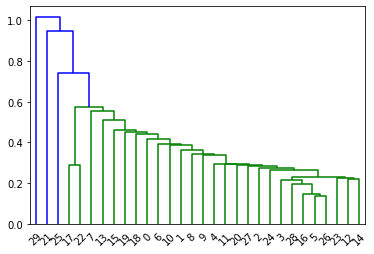

```python
test = hierarchy.linkage(normal, 'single')
dn = hierarchy.dendrogram(test)
```

It looks as though 29, 21, and 25 might be outliers in the group. Upon further inspection of the data I found that 21 used 12 squares of chocolate and 4 cups of chocolate chips, far more than any other recipe, and 25 used a package of yellow cake mix (yuck!), and upon further inspection found that 29 was the only recipe to use confectioners sugar.

```python
swap.loc[[29,21,25]]
```

| Ingredients | (1 ounce) squares german sweet chocolate, chopped | (12 chocolate chips | (18.25 ounce) package yellow cake mix | (3.3 ounce) package instant white chocolate pudding mix | (3.5 ounce) package instant vanilla pudding mix | (6 ounce) package almond brickle chips | C almonds | C brown sugar | C butter | C chocolate chips | ... | T milk | T vanilla extract | t baking powder | t baking soda | t ground cinnamon (optional) | t ground white pepper | t hot water | t salt | t vanilla extract | units eggs |
| --- | --- | --- | --- | --- | --- | --- | --- | --- | --- | --- | --- | --- | --- | --- | --- | --- | --- | --- | --- | --- | --- |
| 29 | 0.0 | 0.0 | 0.0 | 0.0 | 0.0 | 0.0 | 0.0 | 0.0 | 0.0 | 2.0 | ... | 0.0 | 0.0 | 1.5 | 0.0 | 0.0 | 0.0 | 0.0 | 0.25 | 1.5 | 2.0 |
| 21 | 12.0 | 0.0 | 0.0 | 0.0 | 0.0 | 0.0 | 0.0 | 2.0 | 2.0 | 4.0 | ... | 0.0 | 0.0 | 2.0 | 2.0 | 0.0 | 0.0 | 0.0 | 0.00 | 1.0 | 4.0 |
| 25 | 0.0 | 0.0 | 1.0 | 0.0 | 0.0 | 0.0 | 0.0 | 0.0 | 0.5 | 2.0 | ... | 0.0 | 0.0 | 0.0 | 0.0 | 0.0 | 0.0 | 0.0 | 0.00 | 1.0 | 2.0 |

3 rows × 33 columns

After removing those I tested the new dataset and found the following dendrogram, which showed 17 and 21 to be possible outliers.

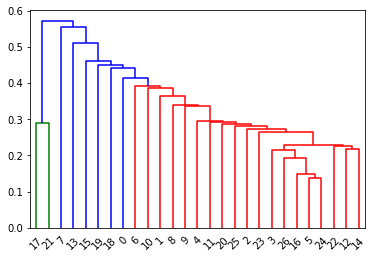

```python
swap.drop([21,25,29],inplace=True)
normal = Normalizer().fit_transform(swap)
test = hierarchy.linkage(normal, 'single')
dn = hierarchy.dendrogram(test)
```

I removed those recipes and found a dataset that looked much cleaner for processing.

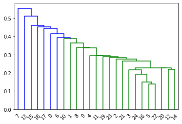

```python
swap.drop([17,22],inplace=True)
normal = Normalizer().fit_transform(swap)
test = hierarchy.linkage(normal, 'single')
dn = hierarchy.dendrogram(test)
```

The machine learning algorithm I chose for this project was the KMeans algorithm, which is a relatively simple clustering algorithm which partitions each vector into a predetermined number clusters in which each vector belongs to the cluster with the nearest mean. The center of each cluster represent the mean (average) of the group. The dendrogram appears to show 2 groups emerging from the pack, so I chose to used 2 clusters for the KMeans algorithm.

```python
kmeans = KMeans(n_clusters=2,n_init=50)
kmeans.fit(normal)
kmeans.predict(normal)
centers = kmeans.cluster_centers_
```

Here is an example of one of the KMeans recipes. After a bit of cleaning up, this will be one of our new recipes!

```python
print(centers[0])
```

```
[ 0.00000000e+00  9.54471826e-03  0.00000000e+00  9.14066663e-03
  2.06761147e-02  1.16722792e-02  3.17520323e-03  1.78020506e-01
  1.95645696e-01  4.26598558e-01  5.13288118e-03  9.54471826e-03
  6.39101187e-03  0.00000000e+00  5.13288118e-03  5.22861877e-01
  1.03380574e-02  8.93200379e-03  1.13877495e-02  3.29161065e-02
  6.47716610e-02  1.58269536e-01  0.00000000e+00 -1.38777878e-17
  1.68543549e-02  3.43878240e-02  2.26178834e-01  4.77235913e-03
  8.64180861e-03  1.58102767e-02  1.26633283e-01  2.94510588e-01
  4.12400789e-01]
```

## A Little More Tidying Up

First, I stored these new recipes in a dataframe to do some processing.

```python
# Create a new dataframe to store kmeans recipes
recipes = pd.DataFrame(columns=['Recipe 1','Recipe 2'])
# Add ingredient column
recipes['Ingredients'] = master.index
# Add both recipes to dataframe
for i in range(len(centers)):
    recipes['Recipe ' + str(i+1)] = centers[i]
```

At this point, the measurements are still normalized from 0-1, so in order to return them to a useful state, I had to rescale them to a known measurement. I chose to base all the recipes on using a single egg, as I would rather use 3/4 cups of flour than 3/4s of an egg.

```python
for i in range(len(recipes)):
    for j in range(2):
        # Rescale the measurements using egg as the basis
        recipes.at[i,'Recipe ' + str(j+1)] = recipes.at[i,'Recipe ' + str(j+1)]/recipes.at[32,'Recipe ' + str(j+1)]
        # Round to the nearest 2 decimal places
        recipes.at[i,'Recipe ' + str(j+1)] = round(recipes.at[i,'Recipe ' + str(j+1)],2)
        # Round to the nearest 1/4
        recipes.at[i,'Recipe ' + str(j+1)] = round(recipes.at[i,'Recipe ' + str(j+1)]*4)/4
```

Next I separated the recipes into their own dataframes.

```python
recipe1,recipe2= pd.DataFrame(),pd.DataFrame()
for i in range(len(recipes)):
    recipe1 = recipe1.append({'Ingredients': recipes.at[i,'Ingredients'], 'Measurements': recipes.at[i,'Recipe 1']},ignore_index=True)
    recipe2 = recipe2.append({'Ingredients': recipes.at[i,'Ingredients'], 'Measurements': recipes.at[i,'Recipe 2']},ignore_index=True)
```

From here I can remove any ingredients with 0 values and print a readable recipe for baking!

```python
recipe1.query('Measurements != 0', inplace=True)
recipe1.index = np.arange(1, len(recipe1)+1)
recipe1
```

|  | Ingredients | Measurements |
| --- | --- | --- |
| 1 | C brown sugar | 0.50 |
| 2 | C butter | 0.50 |
| 3 | C chocolate chips | 1.00 |
| 4 | C flour | 1.25 |
| 5 | C walnuts | 0.25 |
| 6 | C white sugar | 0.50 |
| 7 | t baking soda | 0.50 |
| 8 | t salt | 0.25 |
| 9 | t vanilla extract | 0.75 |
| 10 | units eggs | 1.00 |

```python
recipe2.query('Measurements != 0', inplace=True)
recipe2.index = np.arange(1, len(recipe2)+1)
recipe2
```

|  | Ingredients | Measurements |
| --- | --- | --- |
| 1 | C brown sugar | 1.00 |
| 2 | C butter | 0.75 |
| 3 | C chocolate chips | 1.50 |
| 4 | C flour | 2.00 |
| 5 | C walnuts | 0.25 |
| 6 | C white sugar | 0.50 |
| 7 | T milk | 2.00 |
| 8 | T vanilla extract | 0.50 |
| 9 | t baking soda | 0.75 |
| 10 | t salt | 1.00 |
| 11 | t vanilla extract | 0.50 |
| 12 | units eggs | 1.00 |

## The Aftermath

Now I have 2 machine learning developed cookie recipes to try out. This was such a fun project, and really satisfying to combine my love of baking and my passion for data science. Now it's time to see how these new cookies compare to my own! Machine learning vs Me!